# Visualizing and Analyzing Soccer Trades Across Europe

## Bringing it all together

#### Now that we have all our datasets, lets clean and combine them so we can do our analysis

```python
# import packages
# !pip install fuzzywuzzy # if you havent downloaded the package before, uncomment this line
import pandas as pd
import numpy as np
import matplotlib.pyplot as plt
from fuzzywuzzy import process
import plotly.graph_objects as go
from plotly.subplots import make_subplots
import seaborn as sns

import warnings
warnings.filterwarnings("ignore")
```

```python
# load our different datasets
results = pd.read_csv('league_results.csv', index_col = 0)
trades = pd.read_csv('trades_not_cleaned.csv', index_col = 0)
stadiums = pd.read_csv('stadiums.csv', index_col = 0)
```

### Data Cleaning

All the different data sources have slight variations when it comes to team names - which will prove challenging when trying to group things by specific teams!

For our analysis, we are going to anchor on the trades table as our 'source of truth' for team names

```python
# eliminate the * character from team names, and strip white spaces captured when web scraping
trades.To = trades.To.str.strip()
trades.From = trades.From.str.strip()

results.Team = results.Team.str.replace(' \*', '').str.strip()
results.Team = results.Team.str.replace('Borussia', 'Bor.')
stadiums.Team = stadiums.Team.str.replace('Borussia', 'Bor.')
stadiums.Team = stadiums.Team.str.replace('1. ', '')
```

### Cleaning up some of the team names

Let's clean up some of the team names so that way we can compare trades across teams on a consistent dataset

> Let's clean up the English team names first

```python
# create a mapping for the terms we want to preserve from the English League

eng_map = {'Tottenham Hotspur':'Tottenham',
           'Wolverhampton Wanderers':'Wolverhampton',
           'Brighton and Hove Albion':'Brighton',
           'Cardiff City':'Cardiff',
           'Huddersfield Town':'Huddersfield',
           'West Bromwich Albion':'West Brom',
           'Norwich City':'Norwich',
           'Queens Park Rangers': 'QPR',
           'Bolton Wanderers':'Bolton',
           'Blackburn Rovers':'Blackburn',
           'Birmingham City':'Birmingham'}
```

> Let's clean up the Italian team names

```python
# create a mapping for the terms we want to preserve from the Italian league

ita_map = {'Spal':'SPAL',
           'Atlanta':'Atalanta',}
```

> Let's clean up the German team names

```python
# create a mapping for the terms we want to preserve from the German league

ger_map = {"M'gladbach":'Bor. Mgladbach',
           'Bor. Mönchengladbach':'Bor. Mgladbach',
           'Bor. MGladbach':'Bor. Mgladbach',
           'Eintract Frankfurt':'Eint. Frankfurt',
           'Eintracht':'Eint. Frankfurt',
           'Fortuna DÃ¼sseldorf':'Fortuna',
           'FC Augsburg':'Augsburg',
           'Hannover 96':'Hannover',
           'FC Nurnberg':'Nurnberg',
#            'Cologne':'',
           'FC Ingolstdat 04':'Ingolstadt',
           'SV Darmstadt 98':'Darmstadt',
           'SC Paderborn 07':'Paderborn',
           'Eintracht Branuschweig':'Braunschweig',
           'Energie Cottbus':'Cottbus',
           'Karlsruher SC':'Karlsruher',
           'Borussia Dortmund':'Bor. Dortmund',
           'Bayer 04 Leverkusen': 'Bayer Leverkusen',
           'FC Schalke 04':'Schalke',
           'FSV Mainz 05':'Mainz',
           'TSG 1899 Hoffenheim':'Hoffenheim',
           'FC Köln': '1FC Köln'}
```

> Let's clean up the team names from Spain

```python
# create a mapping for the terms we want to preserve from the Spanish league

spa_map = {'Zaragoza':'Real Zaragoza',
           'SD Huesca':'Huesca',
           'Xeres':'Deportivo Xerez',
           'Recreativo':'Recreativo de Huelva',
           'Recreativo Huelva':'Recreativo de Huelva',
           'Atlectico Madrid':'Atletico Madrid',
           'FC Barcelona':'Barcelona'}
```

```python
# create a function to replace keys/values given a provided map

def map_items(league_map):
    for k,v in league_map.items():
        results.Team[results.Team == k] = v
        trades.To[trades.To == k] = v
        trades.From[trades.From == k] = v
        stadiums.Team[stadiums.Team == k] = v
    print('Complete')
```

```python
# loop through keys and values to replace values across the various datasets
map_items(eng_map)
map_items(ita_map)
map_items(ger_map)
map_items(spa_map)
```

```
Complete
Complete
Complete
Complete
```

Finally - now we can strip whitespace from any names in our dataset and merge each of the individual data frames into one

```python
# subset our data to teams that have stadiums we can plot
data = trades[(trades.To.isin(stadiums.Team)) & (trades.From.isin(stadiums.Team))]

# apply the strip function anywhere we have a string column
data = data.applymap(lambda x: x.strip() if isinstance(x, str) else x)
```

```python
# merge the trades dataset with the stadiums dataset, keeping the coordinates of the 'To' team
data = data.merge(stadiums, how = 'left', left_on = 'To', right_on = 'Team')
data.rename({'Team':'Team_To', 'Stadium':'Stadium_To', 'Lat':'Lat_To', 'Lon':'Lon_To'},
           axis = 1, inplace = True)
```

```python
# merge the trades dataset with the stadiums dataset, keeping the coordinates of the 'From' team
data = data.merge(stadiums, how = 'left', left_on = 'From', right_on = 'Team')
data.rename({'Team':'Team_From', 'Stadium':'Stadium_From', 'Lat':'Lat_From', 'Lon':'Lon_From'},
           axis = 1, inplace = True)
```

Now that we have a merged dataset, let's clean up the 'Price' column so we can perform some calculations on those values

```python
def price_convert(x):

    # identify all the values to replace
    y = str(x).replace('million', '+1_000_000')\
        .replace('miillion', '+1_000_000')\
        .replace(',', '')\
        .replace('€', '')\
        .replace('\*', '')\
        .replace('(50%)', '')\
        .replace('(', '')\
        .replace(')','')\
        .strip()\
        .split('+')

# if there are two values returned from the split (because we're splitting on the '+' we added)
# try to multiply the two together (turning 1million to 1*1_000_000) otherwise
# try to return the float value of the string, or return the initial value if it cant be done
    if len(y) > 1:
        return(int(np.multiply(float(y[0]),float(y[1]))))
    else:
        try:
            return(float(y[0]))
        except:
            return(y[0])
```

```python
# apply our price function to every value in the price column
data.Price = data.Price.apply(lambda x: price_convert(x))
```

### Trades Dates and Transfer Windows

Finally - let's fix the dates so that we know which trades took place in which seasons.

This is made slightly difficult because different leagues have 'mid-season' trades, where a transfer executed in January 2018 actually effects the 2017/2018 season, whereas a trade executed in June 2018 effects the 2018/2019 season.

Here is a table showing when transfer windows are open/closed:

| League | Summer Open | Summer Close | Winter Open | Winter Close |
| --- | --- | --- | --- | --- |
| England | May | August | January | January |
| Italy | July | September | January | January |
| Germany | July | September | January | February |
| Spain | July | September | January | February |

**If we want to capture the correct season, anything before March should be assigned to the 'previous season' whereas anything after March should be assigned to that years season**

```python
# combine the date and year variables into a new datetime column
data['transfer_season'] = data.Date.str.cat(data.Year.map(str), sep = ' ')
data['transfer_season'] = pd.to_datetime(data['transfer_season'])

# replace the year column where our transfer window rules are/arent met
data['transfer_season'] = np.where(data.transfer_season.dt.month < 3,
                                   data.transfer_season.dt.year - 1,
                                   data.transfer_season.dt.year)
```

## Data Analysis

Now that we have our cleaned data - let's define a function to map various trades across Europe

```python
def draw_trades(entry, df, mode):

    # if we are looking at team, check the to and from columns, and assign a color column
    if mode == 'Team':

        if type(entry) != str:

            test = df[(df.Team_To.isin(entry) | (df.Team_From.isin(entry)))].copy().reset_index()

        else:

            test = df[(df.Team_To == entry) | (df.Team_From == (entry))].copy().reset_index()

        test['stringcolor'] = np.where(test.Team_To == entry, 'red', 'blue')

    # if we are looking at player, check the player column, and assign a color column
    elif mode == 'Player':

        if type(entry) != str:

            test = df[(df.Player.isin(entry))].copy().reset_index()

        else:

            test = df[(df.Player == entry)].copy().reset_index()

        test['stringcolor'] = 'black'

    # if we don't return any values, try to return a fuzzy-matched string of what the
    # user may have been trying to input
    if len(test) == 0:

        if mode == 'Player':
            value = process.extractOne(entry, df.Player)[0]

        elif mode == 'Team':
            value = process.extractOne(entry, df.Team_To.append(df.Team_From).unique())[0]

        print('No entries found. Did you mean: ' + str(value) + '?')

    # if everything looks good, let's build our map using plotly go
    else:
        fig = go.Figure()

    # add our 'from' points
        fig.add_trace(go.Scattergeo(
            locationmode = 'ISO-3',
            lon = test['Lon_From'],
            lat = test['Lat_From'],
            hoverinfo = 'text',
            mode = 'markers',
            marker = dict(
                size = 4,
                color = 'rgb(255, 0, 0)',
                line = dict(
                    width = 3,
                    color = 'rgba(68, 68, 68, 0)'
                )
            )))

    # add our 'to' points
        fig.add_trace(go.Scattergeo(
            locationmode = 'ISO-3',
            lon = test['Lon_To'],
            lat = test['Lat_To'],
            hoverinfo = 'text',
            mode = 'markers',
            marker = dict(
                size = 4,
                color = 'rgb(0, 0, 255)',
                line = dict(
                    width = 3,
                    color = 'rgba(68, 68, 68, 0)'
                )
            )))

        # loop through our points and draw line traces between the 'to' and 'from' points
        # where the color depends on the movement
        for i in range(len(test)):
            fig.add_trace(
                go.Scattergeo(
                    locationmode = 'ISO-3',
                    lon = [test['Lon_From'][i], test['Lon_To'][i]],
                    lat = [test['Lat_From'][i], test['Lat_To'][i]],
                    mode = 'lines',
                    line = dict(width = 1,color = test['stringcolor'][i]),
                    hoverinfo = 'text',
                    text = ['(From) ' + test['Team_From'][i] + ': ' + test['Player'][i] + ' (' + str(test['Year'][i]) + ')',
                            '(To) ' + test['Team_To'][i] + ': ' + test['Player'][i] + ' (' + str(test['transfer_season'][i]) + ')']
                )
            )


        # update our title and figure details
        fig.update_layout(
            title_text = 'Trades Across Four Major European Soccer Leagues<br \>' + 'For: ' + entry,
            showlegend = False,
            geo = go.layout.Geo(
                scope = 'europe',
                projection_type = 'azimuthal equal area',
                showland = True,
                landcolor = 'rgb(243, 243, 243)',
                countrycolor = 'rgb(204, 204, 204)',
            ),
        )

        # if our mode is 'Team', add a legend to specify 'to' and 'from' trace colors
        if mode == 'Team':
            fig.update_layout(
                showlegend=False,
                annotations=[
                    go.layout.Annotation(
                        x=0,
                        y=1,
                        showarrow = False,
                        text="TO " + entry,
                        font=dict(
                            color="red")
                    )
                , go.layout.Annotation(
                        x=0,
                        y=0.9,
                        showarrow = False,
                        text="FROM " + entry,
                        font=dict(
                            color="blue")
                )]
            )

        fig.show()

        # return a dataframe containing all of the plotted information
        a = pd.DataFrame(test[['Date', 'Year', 'Player', 'Position', 'Price', 'From', 'To', 'transfer_season']])

        if mode == 'Player':
            return a.iloc[::-1]
        else:
            print('TOTAL TRANSFERS: ' + str(a['To'].count()))
            print('TRANSFERS TO: ' + str(a[a.To == entry]['To'].count()))
            print('TRANSFERS FROM: ' + str(a[a.From == entry]['From'].count()))
            print()
            print('TRANSFERS:')
            return a.sort_values('transfer_season', ascending = False)
```

```python
draw_trades('Alexis Sanchez', data, mode = 'Player')
```

[interactive chart not shown]

|  | Date | Year | Player | Position | Price | From | To | transfer_season |
| --- | --- | --- | --- | --- | --- | --- | --- | --- |
| 2 | Jul 21 | 2012 | Alexis Sanchez | Attacker | 26000000 | Udinese | Barcelona | 2012 |
| 1 | Jul 11 | 2015 | Alexis Sanchez | Attacker | 44000000 | Barcelona | Arsenal | 2015 |
| 0 | Jan 22 | 2018 | Alexis Sanchez | Attacker | undisclosed | Arsenal | Manchester United | 2017 |

#### Now that we know who is transfering where (and when)

Let's look at some aggregate statistics about patterns in those trades, and how they potentially influenced winners and losers across leagues

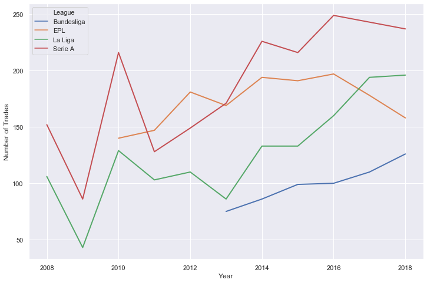

```python
# starting with the overall number of trades per league over time
# (using the full trades dataset since we aren't looking to plot locations)
trades_over_time = trades.groupby(['League', 'Year'])['Player'].count().reset_index()
sns.set()
sns.set(rc={'figure.figsize':(12,8)})
sns.lineplot('Year', 'Player', hue = 'League', data = trades_over_time, lw = 2)
plt.ylabel('Number of Trades')
```

```python
# create a data frame of the number of players traded by nationality
players = trades.drop_duplicates(subset = 'Player', keep = 'last')
nationalities = pd.DataFrame(players['Nationality'].str.strip().value_counts()).reset_index()
nationalities.columns = ['Country', 'Trade Count']
nationalities['Country'][nationalities.Country == 'England'] = 'United Kingdom'
```

```python
fig = go.Figure(data=go.Choropleth(
    locations=nationalities['Country'].astype(str),
    z = nationalities['Trade Count'].astype(float),
    locationmode = 'country names',
    autocolorscale = False,
    colorscale = 'Blues',
    colorbar_title = "Number of Trades"
))

fig.update_layout(
    title_text = 'Number of Trades by Player Nationalities'
)

fig.show()
```

[interactive chart not shown]

```python
nationalities.head(10)
```

|  | Country | Trade Count |
| --- | --- | --- |
| 0 | Spain | 371 |
| 1 | Italy | 328 |
| 2 | United Kingdom | 277 |
| 3 | France | 186 |
| 4 | Brazil | 176 |
| 5 | Argentina | 171 |
| 6 | Germany | 158 |
| 7 | Netherlands | 88 |
| 8 | Portugal | 84 |
| 9 | Serbia | 70 |

As we can see, most of the players transfering to and from teams in these european leagues are either from European or South American countries.

What about the total amount of money being transfered though?

```python
# let's plot the amount of money in trades by country

# drop values we don't need
prices = data[~data.Price.isin(['Free',
                                'Loan',
                                'undisclosed',
                                'undislcosed',
                                'co-ownership',
                                'Swap',
                                'n/a'])].reset_index()

# group our data
value_country = prices.groupby('Nationality')['Price'].sum().reset_index()


# construct our plot
fig = go.Figure(data=go.Choropleth(
    locations=value_country['Nationality'].astype(str),
    z = value_country['Price'].astype(float).round(2),
    locationmode = 'country names',
    colorscale = 'Blues',
    colorbar_title = "Dollar Value of Trades",
))

fig.update_layout(
    title_text = 'Total Dollar Value of Trades by Player Nationalities'
)

fig.show()
```

[interactive chart not shown]

```python
# check the top countries by monetary trade value
a = value_country.sort_values('Price', ascending = False).head(10)
a.Price = a.Price.apply(lambda x: '$ {:.1f}M'.format(x/1_000_000))
a.reset_index().drop(columns = 'index').rename(columns = {'Price':'Total Trade Value'})
```

|  | Nationality | Total Trade Value |
| --- | --- | --- |
| 0 | Spain | $ 1071.2M |
| 1 | England | $ 866.1M |
| 2 | France | $ 368.8M |
| 3 | Italy | $ 358.8M |
| 4 | Germany | $ 329.7M |
| 5 | Argentina | $ 308.9M |
| 6 | Brazil | $ 286.3M |
| 7 | Belgium | $ 258.7M |
| 8 | Uruguay | $ 150.0M |
| 9 | Netherlands | $ 139.4M |

```python
# define our function to determine the type of trade
def trade_value(x):
    if (isinstance(x, int) | isinstance(x, float)):
        return 'Monetary'
    elif x == 'Loan':
        return 'Loan'
    elif x == 'Free':
        return 'Free'
    else:
        return 'Other'
```

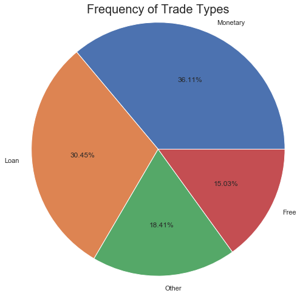

```python
# plot our frequency of trade types
data['Trade_Type'] = [trade_value(x) for x in data.Price]
data.Trade_Type.value_counts().plot(kind = 'pie', autopct = '%.2f%%', radius = 1.2)
plt.ylabel('')
plt.title('Frequency of Trade Types', fontsize = 20)
```

So players are only traded for money about 1/3 of the time - which means the total trade value in terms of dollars may not be the best measure of trade value. Let's see if we can figure out another way to measure value

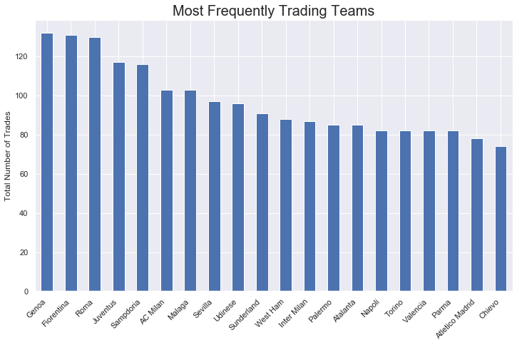

```python
# plot the teams that trade the most freqently over the years
trades.To.value_counts().head(20).plot(kind = 'bar',
                                       figsize = (12,7))
plt.xticks(rotation = 45, ha = 'right')
plt.title('Most Frequently Trading Teams',fontsize = 20)
plt.ylabel('Total Number of Trades')
```

So now that we know which teams trade the most - can we see how they did?

```python
# make our function to plot results by team
def plot_results(team, df, metric):

    fig = make_subplots(specs=[[{"secondary_y": True}]])

    data = df[df.Team == team]

    if data.shape[0] != 0:

        # Add traces
        fig.add_trace(
            go.Bar(x=data.Year, y=data[metric], name = metric),
            secondary_y=False,
        )

        fig.add_trace(
            go.Scatter(x=data.Year, y=data['Position'], name= 'Position'),
            secondary_y=True,
        )

        # Add figure title
        fig.update_layout(
            title_text= team + ' Performance over Time'
        )

        # Set x-axis title
        fig.update_xaxes(title_text="Year")

        # Set y-axes titles
        fig.update_yaxes(title_text="<b>primary: </b> " + metric, secondary_y=False)
        fig.update_yaxes(title_text="<b>secondary: </b> Position", secondary_y=True, autorange = 'reversed')

        fig.show()
    else:
        print('No results found. Did you mean: ' +  process.extractOne(team, results.Team.unique())[0])
```

```python
# let's see the metrics we have available to compare
[i for i in results.columns[results.columns.values != 'Team']]
```

```
['Position',
 'Played',
 'W',
 'D',
 'L',
 'GF',
 'GA',
 'GD',
 'PTS',
 'Year',
 'League']
```

```python
# function to explore metrics against the final position in the league
plot_results('Manchester United', results, metric = 'W')
```

[interactive chart not shown]

```python
# re-do our transfer season calculations
trades['transfer_season'] = trades.Date.str.cat(trades.Year.map(str), sep = ' ')
trades['transfer_season'] = pd.to_datetime(trades['transfer_season'])

# replace the year column where our transfer window rules are/arent met
trades['transfer_season'] = np.where(trades.transfer_season.dt.month < 3,
                                   trades.transfer_season.dt.year - 1,
                                   trades.transfer_season.dt.year)
```

```python
# calculate a data frame containing the total number of trades by team and year
To = pd.DataFrame(trades.groupby(['transfer_season', 'To'])['Player'].count().reset_index())
To = To.rename(columns={'To':'Team', 'Player':'To'})

From = pd.DataFrame(trades.groupby(['transfer_season', 'From'])['Player'].count().reset_index())
From = From.rename(columns={'From':'Team', 'Player':'From'})

# join our to and from dataframe
trade_count = To.merge(From, how = 'inner', on = ['transfer_season', 'Team'])
trade_count.shape
```

```
(705, 4)
```

```python
# create a total dataframe containing the to and from trades with results
total = trade_count.merge(results,
                          how = 'inner',
                          left_on = ['transfer_season', 'Team'],
                          right_on = ['Year', 'Team']).drop(columns = ['transfer_season'])
total.head()
```

|  | Team | To | From | Position | Played | W | D | L | GF | GA | GD | PTS | Year | League |
| --- | --- | --- | --- | --- | --- | --- | --- | --- | --- | --- | --- | --- | --- | --- |
| 0 | Atalanta | 5 | 6 | 11 | 38 | 13 | 8 | 17 | 45 | 49 | -4 | 47 | 2008 | serie a |
| 1 | Atletico Madrid | 10 | 7 | 4 | 38 | 20 | 7 | 11 | 80 | 57 | 23 | 67 | 2008 | la liga |
| 2 | Barcelona | 5 | 3 | 1 | 38 | 27 | 6 | 5 | 105 | 35 | 70 | 87 | 2008 | la liga |
| 3 | Cagliari | 4 | 3 | 9 | 38 | 15 | 8 | 15 | 49 | 50 | -1 | 53 | 2008 | serie a |
| 4 | Catania | 4 | 3 | 15 | 38 | 12 | 7 | 19 | 41 | 51 | -10 | 43 | 2008 | serie a |

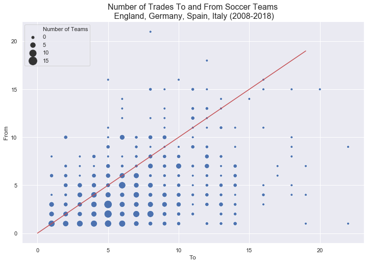

```python
# plot number of trades per team by To and From counts
a=total.groupby(['To', 'From'])['Team'].count()
a=a.reset_index().rename(columns={'Team':'Number of Teams'})

sns.scatterplot('To', 'From', data = a, size = 'Number of Teams', sizes = (25,250))
x = range(20)
plt.plot(x,x,color = 'r')
plt.title('Number of Trades To and From Soccer Teams\n England, Germany, Spain, Italy (2008-2018)', fontsize = 16)
plt.show()
```

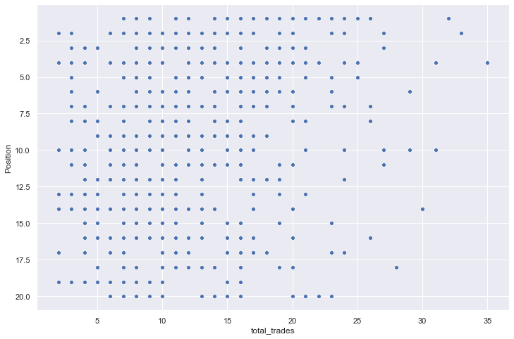

```
Correlation is: 0.20616711597990253
```

```python
# Let's now check out how the total number of trades impacts standings
total['total_trades'] = total['To'] + total['From']

ax = sns.scatterplot('total_trades', 'Position', data = total)
ax.invert_yaxis()
plt.show()

print('Correlation is: ' + str(-1 * np.corrcoef(total.total_trades, total.Position)[0,1]))
```

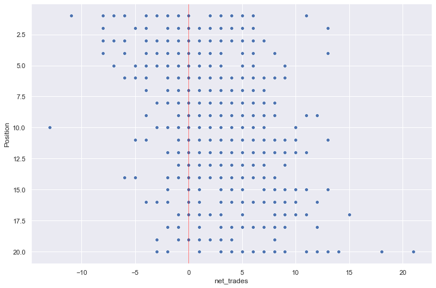

```
Correlation is: -0.3770866876435351
```

```python
# Since there's not much to decern here, let's now check out how the net number of trades (To - From) impacts standings
total['net_trades'] = total['To'] - total['From']
ax = sns.scatterplot('net_trades', 'Position', data = total)
ax.invert_yaxis()
plt.axvline(x = 0, color = 'red', linewidth = 0.5)
plt.show()
print('Correlation is: ' + str(-1 * np.corrcoef(total.net_trades, total.Position)[0,1]))
```

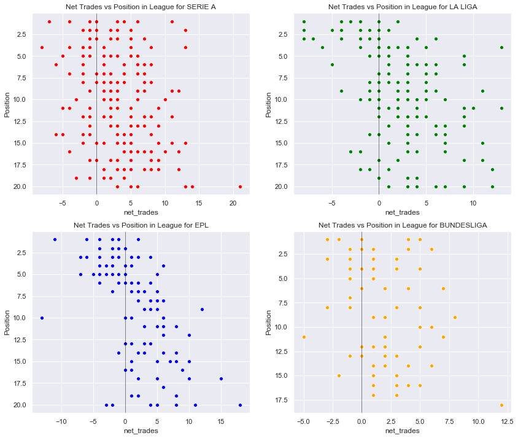

```python
# let's check out net trades for each league
colors = ['red', 'green', 'blue', 'orange']
plt.figure(figsize = (14,12))
for i in range(4):
    plt.subplot(2,2,i+1)
    lg = total.League.unique()[i]
    test = total[total.League == lg]
    ax = sns.scatterplot('net_trades', 'Position', data = test, color = colors[i])
    ax.invert_yaxis()
    plt.title('Net Trades vs Position in League for ' + lg.upper())
    plt.axvline(x = 0, color = 'black', linewidth = 0.5)
```

```python
# Now let's look at these trades by position (by repeating a lot of our same calculations)
To = pd.DataFrame(trades.groupby(['transfer_season', 'To', 'Position'])['Player'].count().reset_index())
To = To.rename(columns={'To':'Team', 'Player':'To', 'Position':'pos'})

From = pd.DataFrame(trades.groupby(['transfer_season', 'From', 'Position'])['Player'].count().reset_index())
From = From.rename(columns={'From':'Team', 'Player':'From', 'Position':'pos'})

trade_count = To.merge(From, how = 'inner', on = ['transfer_season', 'Team', 'pos'])

total_position = trade_count.merge(results,
                          how = 'inner',
                          left_on = ['transfer_season', 'Team'],
                          right_on = ['Year', 'Team']).drop(columns = ['transfer_season'])
total_position.head()
```

|  | Team | pos | To | From | Position | Played | W | D | L | GF | GA | GD | PTS | Year | League |
| --- | --- | --- | --- | --- | --- | --- | --- | --- | --- | --- | --- | --- | --- | --- | --- |
| 0 | Atletico Madrid | Midfielder | 1 | 1 | 9 | 38 | 13 | 8 | 17 | 57 | 61 | -4 | 47 | 2009 | la liga |
| 1 | Fiorentina | Defender | 1 | 1 | 11 | 38 | 13 | 8 | 17 | 48 | 47 | 1 | 47 | 2009 | serie a |
| 2 | Genoa | Attacker | 1 | 2 | 9 | 38 | 14 | 9 | 15 | 57 | 61 | -4 | 51 | 2009 | serie a |
| 3 | Inter Milan | Midfielder | 1 | 2 | 1 | 38 | 24 | 10 | 4 | 75 | 34 | 41 | 82 | 2009 | serie a |
| 4 | Juventus | Midfielder | 1 | 1 | 7 | 38 | 16 | 7 | 15 | 55 | 56 | -1 | 55 | 2009 | serie a |

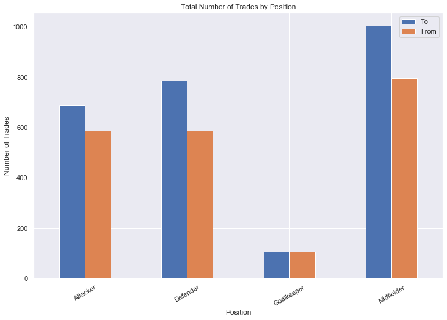

```python
# charting the number of trades to and from teams by position
total_position['Total'] = total_position['To'] + total_position['From']
total_position['Net'] = total_position['To'] - total_position['From']
total_position.groupby('pos')['To', 'From'].sum().plot(kind = 'bar')
plt.xlabel('Position')
plt.ylabel('Number of Trades')
plt.title('Total Number of Trades by Position')
plt.xticks(rotation = 30)
```

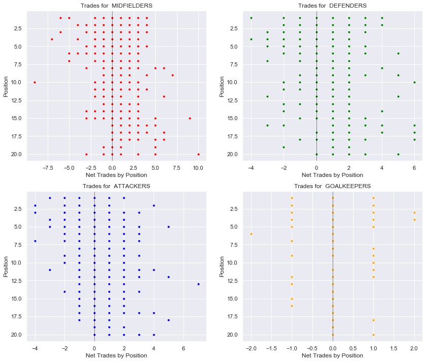

```python
# let's check out net trades for each position
colors = ['red', 'green', 'blue', 'orange']
plt.figure(figsize = (14,12))
for i in range(4):
    plt.subplot(2,2,i+1)
    pos = total_position.pos.unique()[i]
    test = total_position[total_position.pos == pos]
    ax = sns.scatterplot('Net', 'Position', data = test, color = colors[i], s = 25)
    ax.invert_yaxis()
    plt.xlabel('Net Trades by Position')
    plt.axvline(x = 0, color = 'black', linewidth = 0.5)
    plt.title('Trades for  ' + pos.upper() + 'S')
```

So it looks like there's not much of a trend between the specific position being traded for and the subsequent results - however the net number of trades does appear to be somewhat correlated with standings in a league at the end of the season

```python
# let's check out net trades for each position
def check_impact(metric):
    metrics = ['GF', 'GA', 'W', 'D', 'L', 'GD', 'PTS']

    if metric not in ['GF', 'GA', 'W', 'D', 'L', 'GD', 'PTS']:
        print('Metric not found. Please choose one of the following:')
        return metrics
    else:

        colors = ['red', 'green', 'blue', 'orange']
        plt.figure(figsize = (14,12))

        for i in range(4):
            plt.subplot(2,2,i+1)
            pos = total_position.pos.unique()[i]
            test = total_position[total_position.pos == pos]
            cor = round(np.corrcoef(test.Net, test[metric])[0][1],4)
            ax = sns.stripplot('Net', metric, data = test, color = colors[i])
            plt.xlabel('Net Trades by Position')
            plt.ylabel(metric)
            plt.title('Trades for  ' + pos.upper() + 'S (corr: ' + str(cor) + ')')
```

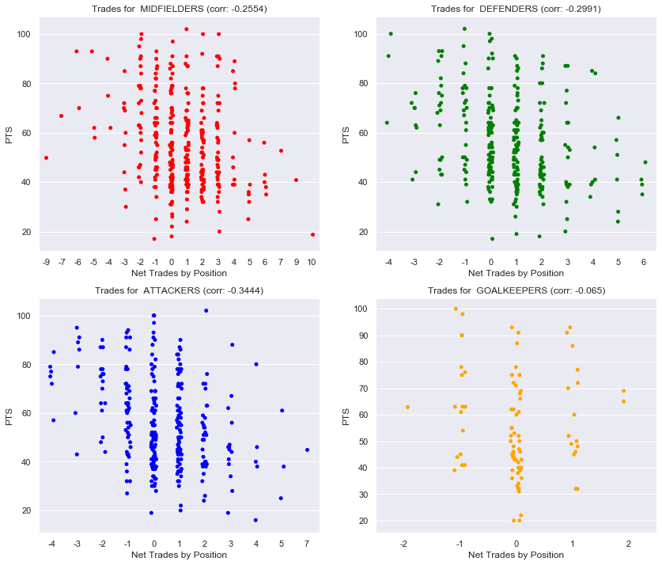

```python
check_impact('PTS')
```

So it looks like net-trades has the biggest impact on standings at the end of the year. Feel free to dig into the data more and see what else you can find!